# week5hw

Week 5 HW - Nicholas Abbasi - discussion notes are at the very end, with code descriptions throughout the notebook.

First, I enter in the data into a data frame from the .csv file, convert the lat and lon to numeric values and then exclude coordinates outside of forest park. Also making sure to include the ggplot2 library.

```r
litdata <- read.table(file = "https://www.evl.uic.edu/aej/424/litterati challenge-65.csv", sep = ",", header = TRUE)
```

```r
litdata$lat <- as.numeric(as.character(litdata$lat))
litdata$lon <- as.numeric(as.character(litdata$lon))
```

```r
litdata <- subset(litdata, (lat > 41.849783 & lat < 41.888720) & (lon < -87.803481 & lon > -87.83) )
```

```r
library(ggplot2)
```

From Project 1 I determined the top 10 users and put them each into seperate dataframes. Each datafram is a filtered through version of the main dataframe, with only the appropriate user's collected trash information stored within each.

```r
user1 <- subset(litdata, grepl("julieta", litdata$username, fixed=TRUE))
user2 <- subset(litdata, grepl("jill-wagner", litdata$username, fixed=TRUE))
user3 <- subset(litdata, grepl("maro-", litdata$username, fixed=TRUE))
user4 <- subset(litdata, grepl("betivere", litdata$username, fixed=TRUE))
user5 <- subset(litdata, grepl("Julianne B", litdata$username, fixed=TRUE))
user6 <- subset(litdata, grepl("rerunvonlinus", litdata$username, fixed=TRUE))
user7 <- subset(litdata, grepl("serenity", litdata$username, fixed=TRUE))
user8 <- subset(litdata, grepl("dimsum22", litdata$username, fixed=TRUE))
user9 <- subset(litdata, grepl("Andrea", litdata$username, fixed=TRUE))
user10 <- subset(litdata, grepl("c-and-h", litdata$username, fixed=TRUE))
```

From Project 1 I determined the top 10 tags and put them each into seperate dataframes. Each datafram is a filtered through version of the main dataframe, with only the appropriate tag's collected trash information stored within each.

```r
tag1 <- subset(litdata, grepl("plastic", litdata$tags, fixed=TRUE))
tag2 <- subset(litdata, grepl("paper", litdata$tags, fixed=TRUE))
tag3 <- subset(litdata, grepl("wrapper", litdata$tags, fixed=TRUE))
tag4 <- subset(litdata, grepl("cup", litdata$tags, fixed=TRUE))
tag5 <- subset(litdata, grepl("bottle", litdata$tags, fixed=TRUE))
tag6 <- subset(litdata, grepl("bag", litdata$tags, fixed=TRUE))
tag7 <- subset(litdata, grepl("cigarette", litdata$tags, fixed=TRUE))
tag8 <- subset(litdata, grepl("candy", litdata$tags, fixed=TRUE))
tag9 <- subset(litdata, grepl("can", litdata$tags, fixed=TRUE))
tag10 <- subset(litdata, grepl("aluminum", litdata$tags, fixed=TRUE))
```

Here each of the dataframes for the top 10 users are plotted onto one graph.

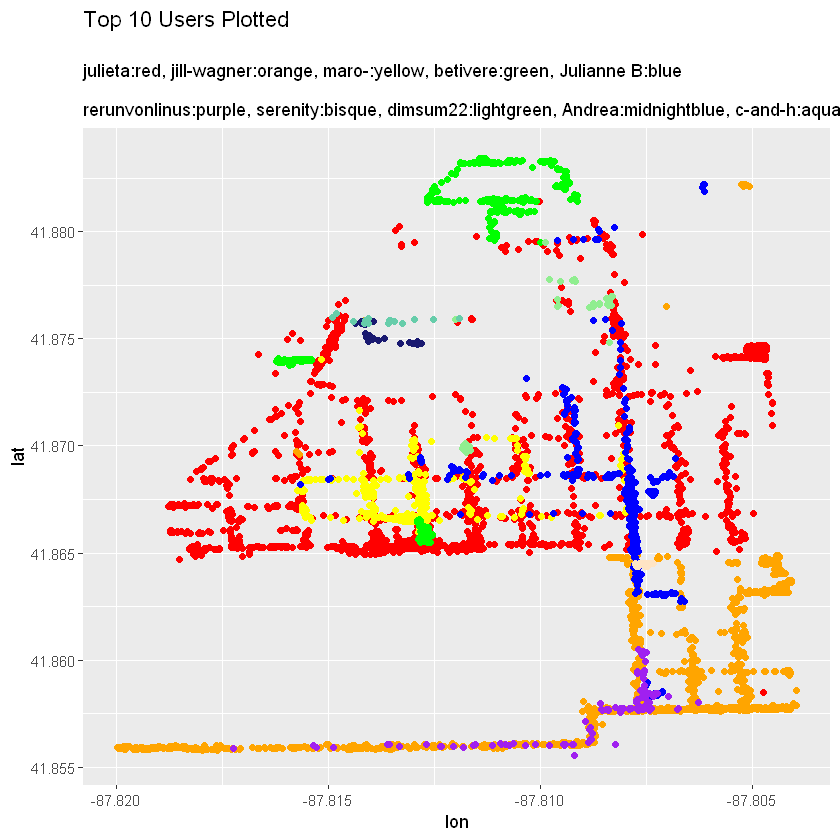

```r
ggplot(user1,aes(lon,lat)) + geom_point(color = "red") +
geom_point(data = user2, color = "orange") +
geom_point(data = user3, color = "yellow") +
geom_point(data = user4, color = "green") +
geom_point(data = user5, color = "blue") +
geom_point(data = user6, color = "purple") +
geom_point(data = user7, color = "bisque") +
geom_point(data = user8, color = "lightgreen") +
geom_point(data = user9, color = "midnightblue") +
geom_point(data = user10, color = "aquamarine3") +
labs(title = "Top 10 Users Plotted\n",
subtitle = "julieta:red, jill-wagner:orange, maro-:yellow, betivere:green, Julianne B:blue\n
rerunvonlinus:purple, serenity:bisque, dimsum22:lightgreen, Andrea:midnightblue, c-and-h:aquamarine3")
```

Now here are the top 3 users plotted.

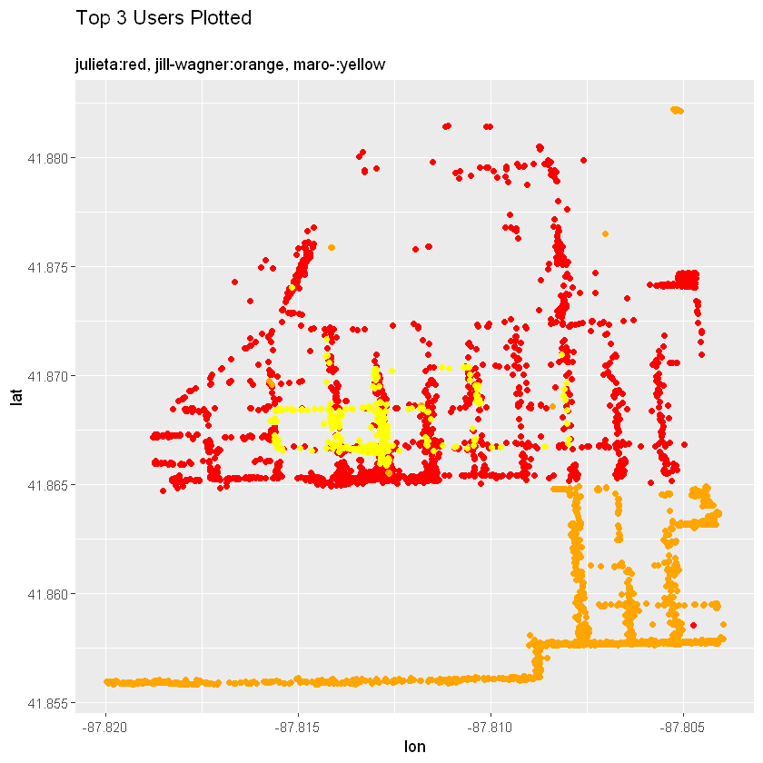

```r
ggplot(user1,aes(lon,lat)) + geom_point(color = "red") +
geom_point(data = user2, color = "orange") +
geom_point(data = user3, color = "yellow") +
labs(title = "Top 3 Users Plotted\n",
subtitle = "julieta:red, jill-wagner:orange, maro-:yellow")
```

And here are the top 4-10 users plotted.

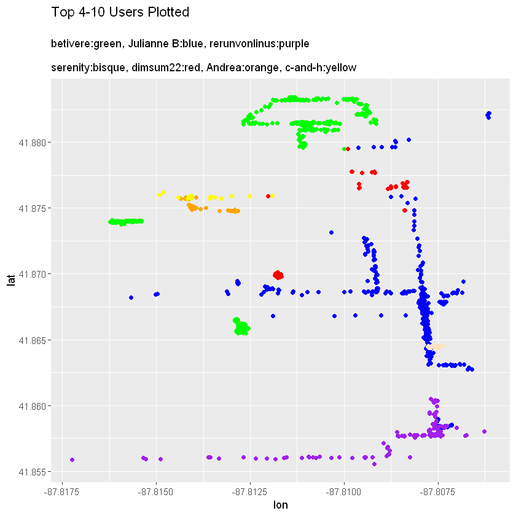

```r
ggplot(user4,aes(lon,lat)) + geom_point(color = "green") +
geom_point(data = user5, color = "blue") +
geom_point(data = user6, color = "purple") +
geom_point(data = user7, color = "bisque") +
geom_point(data = user8, color = "red") +
geom_point(data = user9, color = "orange") +
geom_point(data = user10, color = "yellow") +
labs(title = "Top 4-10 Users Plotted\n",
subtitle = "betivere:green, Julianne B:blue, rerunvonlinus:purple\n
serenity:bisque, dimsum22:red, Andrea:orange, c-and-h:yellow")
```

Here each of the dataframes for the top 10 tags are plotted onto one graph.

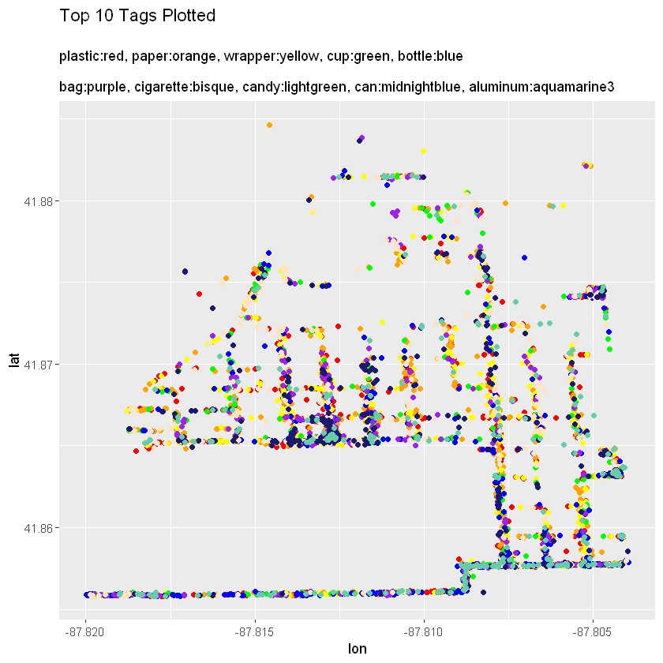

```r
ggplot(tag1,aes(lon,lat)) + geom_point(color = "red") +
geom_point(data = tag2, color = "orange") +
geom_point(data = tag3, color = "yellow") +
geom_point(data = tag4, color = "green") +
geom_point(data = tag5, color = "blue") +
geom_point(data = tag6, color = "purple") +
geom_point(data = tag7, color = "bisque") +
geom_point(data = tag8, color = "lightgreen") +
geom_point(data = tag9, color = "midnightblue") +
geom_point(data = tag10, color = "aquamarine3") +
labs(title = "Top 10 Tags Plotted\n",
subtitle = "plastic:red, paper:orange, wrapper:yellow, cup:green, bottle:blue\n
bag:purple, cigarette:bisque, candy:lightgreen, can:midnightblue, aluminum:aquamarine3")
```

Now here are the top 3 tags plotted.

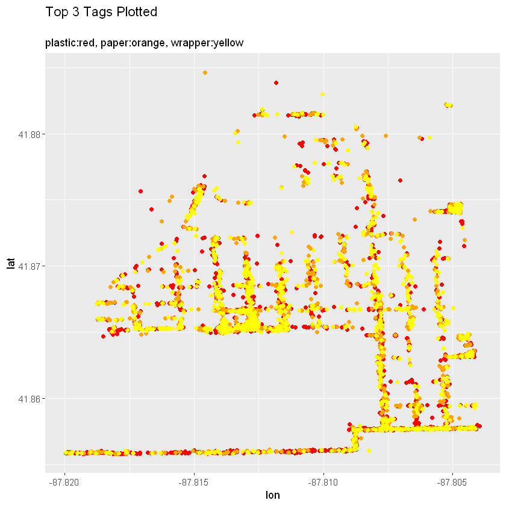

```r
ggplot(tag1,aes(lon,lat)) + geom_point(color = "red") +
geom_point(data = tag2, color = "orange") +
geom_point(data = tag3, color = "yellow")  +
labs(title = "Top 3 Tags Plotted\n",
subtitle = "plastic:red, paper:orange, wrapper:yellow")
```

And here are the top 4-10 tags plotted.

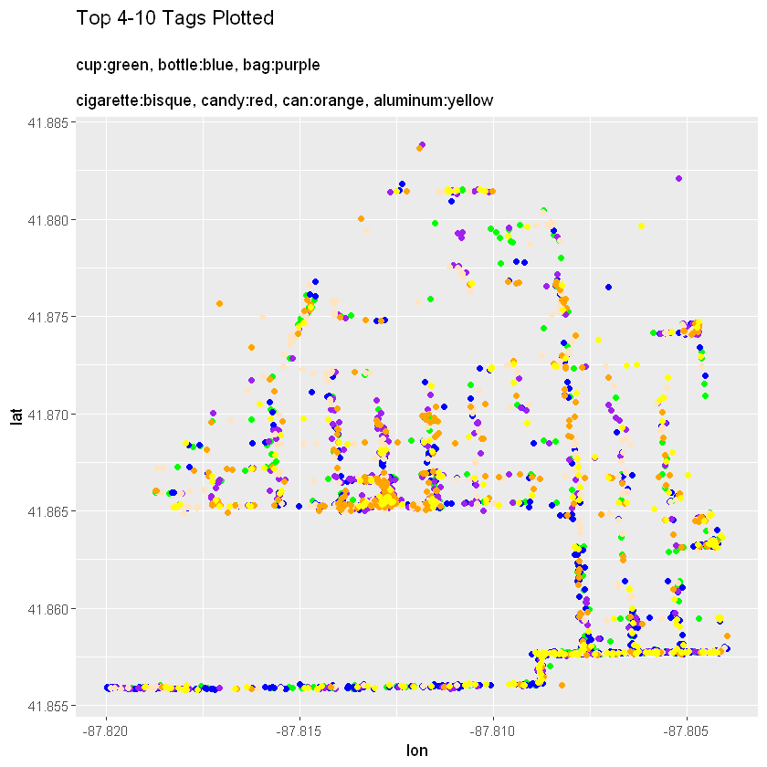

```r
ggplot(tag4,aes(lon,lat)) + geom_point(color = "green") +
geom_point(data = tag5, color = "blue") +
geom_point(data = tag6, color = "purple") +
geom_point(data = tag7, color = "bisque") +
geom_point(data = tag8, color = "red") +
geom_point(data = tag9, color = "orange") +
geom_point(data = tag10, color = "yellow")+
labs(title = "Top 4-10 Tags Plotted\n",
subtitle = "cup:green, bottle:blue, bag:purple\n
cigarette:bisque, candy:red, can:orange, aluminum:yellow")
```

DATA DISCUSSION:

Honestly plotting the information like this in ggplot instead of leafelet does reveal interesting trends that are not as visible with leaflet's clustering. Here being able to see all the points clearly without extra graphics in the way and so plainly instead of it being so hidden shows so much more accurately the hot spots where people find litter. Very clearly it can be seen that litter is found often around main roads in the forest park area. Also, in general it’s pretty neat seeing how obvious the plotted points make up a street grid pattern. Also, I enjoy seeing how the plotting looks when all the information of the top tens are plotted, but also its interesting seeing individual data points isolated into less over crowded groups to see how the top of the tops dominate the collected information.

TOP 10 LITTER PICKERS:

The trends visible in the pickers shows a lot of personality about the people who are picking up the trash. Some tend to focus on a specific more round area, some will dedicate a lot of litter pick up along a long stretch of road, and some, like the work-a-holic julieta, seem to comb the whole village for any and all litter to pick up. Living near this area, I can clearly see that the major roads around 41.85 and 41.865 lat are huge hot spots for litter, which I would expect from personally seeing tons of litter around them and am even happy to know this group is dedicating time to make those hardest hit areas cleaner.

TOP 10 LITTER TAGS:

In general, it seems like the types of litter are pretty spread throughout the map. Looking at the top 3 tags and the lower top 7 tags, the distribution has an almost exact outlined. I will say that the top tags, plastic, paper and wrappers, do make sense being the top kind of litter found. Also, as a person who gets upset knowing how awful smoking is for people and for the environment, it’s very upsetting seeing that cigarettes are on the top 10 most seen kinds of litter. I could see how tagging the type of litter can show some insight into what is going in specific areas where one kind of litter is found often. This allows for more action to be taken to reduce this kind of litter in the area and directly attacking the issue causing it. For cigarettes, it seems clear that people who travel on some of the major roads will likely throw away their cigarettes in the same clustered areas.